# 2-1. 도서관정보찾기_API

```python
d = {"name" : "국가공무원인재개발원"}   #json 형식은 키와 값에 큰따옴표를 사용
print(d["name"])
```

```
국가공무원인재개발원
```

```python
#파이썬 객체를 JSON 문자열로 변환하기 : json.dumps()함수

import json
d_str = json.dumps(d,ensure_ascii = False)   #json.dumps()함수는 아스키 문자 외의 다른 문자를 16진수로 표현, 한글 표현 안됨
                                              # ensure_ascii매개변수를 False로 지정하여 원래 저장된 문자를 그대로 출력
print(d_str)
```

```
{"name": "국가공무원인재개발원"}
```

```python
print(type(d_str))
```

```
<class 'str'>
```

```python
#json 문자열을 파이썬 객체로 변환하기 : json.loads()함수

d2 = json.loads(d_str)
print(d2['name'])
```

```
국가공무원인재개발원
```

```python
print(type(d2))  #문자열이 json.loads()함수를 통해서 파이썬 딕셔너리로 바뀜
```

```
<class 'dict'>
```

```python
d3 = json.loads('{"name": "홍길동","age" : 30, "gender" : "남"}')
print(d3["name"])
print(d3["age"])
print(d3["gender"])
```

```
홍길동
30
남
```

```python
d3 = json.loads('{"name":["홍길동","이하나"],"age" : 30, "gender" : "남"}')
print(d3["name"][1])
```

```
이하나
```

```python
d4_str = '[{"name": "홍길동","age" : 30, "gender" : "남"},{"name": "이하나","age" : 20, "gender" : "여"}]'
d4 = json.loads(d4_str)
print(d4[0]["name"])
```

```
홍길동
```

```python
# json 문자열을 데이터프레임으로 변환하기 : read_json()함수

import pandas as pd
pd.read_json(d4_str)
```

|  | name | age | gender |
| --- | --- | --- | --- |
| 0 | 홍길동 | 30 | 남 |
| 1 | 이하나 | 20 | 여 |

```python
pd.DataFrame(d4)
```

|  | name | age | gender |
| --- | --- | --- | --- |
| 0 | 홍길동 | 30 | 남 |
| 1 | 이하나 | 20 | 여 |

### 파이썬에서 XML 데이터 다루기

#### XML은 eXtensible Markup Language의 약자

- HML은 웹페이지를 표현하는 데는 뛰어나지만, 구조적이지 못함 => 프로그램간의 약속대로 전송하는 API에서는 적절하지 않음
- XML은 엘리먼트(시작태고와 종료태그로 감싼)들이 계층구조를 이루면서 정보를 표현
- 태그는 < 기호로 시작 />기호로 끝남, 시작태그와 종료태그의 이름을 같아야 함
- 태그의 이름은 정보가 잘 드러나도록 정하는 것이 좋다.

```python
# XML 문자열을 파이썬 객체로 변환하기 : fromstring()함수

x_str = """
<book>
    <name> 뉴욕의 영웅이 된 오로르 </name>
    <author> 더글라스 케네디</author>
    <year>2023</year>
</book>
"""
```

```python
#  xml.etree.ElementTree모듈의 fromstring()함수를 사용해 문자열을 xml로 변환

import xml.etree.ElementTree as et
book = et.fromstring(x_str)
```

```python
print(type(book))
```

```
<class 'xml.etree.ElementTree.Element'>
```

```python
print(book.tag)
```

```
book
```

```python
# 자식 엘리먼트 확인하기 => findtext()메서드

book_childs = list(book)  # 리스트로 변환할 때는 list()함수 사용
print(book_childs)
```

```
[<Element 'name' at 0x000002B2936BE430>, <Element 'author' at 0x000002B2936BF6F0>, <Element 'year' at 0x000002B2936BF6A0>]
```

```python
# book_childs 리스트 각 항목을 각각 변수에 할당하고 text 속성으로 엘리먼트 값을 출력

name, author, year = book_childs
print(name.text)
print(author.text)
print(year.text)
```

```
 뉴욕의 영웅이 된 오로르
 더글라스 케네디
2023
```

```python
# findtext()메서드를 사용하여 해당하는 자식 엘리먼트를 탐색

name = book.findtext("name")
author = book.findtext("author")
year = book.findtext("year")
print(name)
print(author)
print(year)
```

```
 뉴욕의 영웅이 된 오로르
 더글라스 케네디
2023
```

```python
x2_str = """
<books>
    <book>
        <name> 뉴욕의 영웅이 된 오로르 </name>
        <author> 더글라스 케네디</author>
        <year>2023</year>
    </book>

    <book>
        <name> 세이노의 가르침 </name>
        <author> 세이노 데이원 </author>
        <year>2023</year>
    </book>
</books>
"""
```

```python
books = et.fromstring(x2_str)
print(books.tag)
```

```
books
```

```python
for book in books.findall('book'):

    name = book.findtext("name")
    author = book.findtext("author")
    year = book.findtext("year")
    print(name)
    print(author)
    print(year)
    print()
```

```
 뉴욕의 영웅이 된 오로르
 더글라스 케네디
2023

 세이노의 가르침
 세이노 데이원
2023
```

```python
# xml을 데이터 프레임을 변환

pd.read_xml(x2_str)
```

|  | name | author | year |
| --- | --- | --- | --- |
| 0 | 뉴욕의 영웅이 된 오로르 | 더글라스 케네디 | 2023 |
| 1 | 세이노의 가르침 | 세이노 데이원 | 2023 |

### API란?

- Application Programming Interface (애플리케이션 프로그래밍 인터페이스)
- 애플리케이션(스마트폰, 카카오톡 서버 등 서로 다른 프로그램)이 인터페이싱하는(요청과 응답을 주고받는) 체계"라고 이해

#### Open API

- "누구나 쓸 수 있도록 공개된(Open) API"
- 대표적으로, 정부의 공공데이터포털(www.data.go.kr)로 해당 사이트를 통해 국가기관이 보유한 수많은 데이터를 API 형태로 무료 공개
- 카카오, 네이버, Google 등 수많은 민간 기업들 또한 자사가 제공하는 다양한 기능들(지도 앱, 포털 검색하기, 로그인 기능 등)을 일반 사람들도 무료로 사용할 수 있도록 API 형태로 제공

### API로 20대가 가장 좋아하는 도서 찾기

- 도서관 정보나루 사이트 접속
- api 호출키 받기

```
* 호출 url : http://data4library.kr/api/loanItemSrch
* 파라미터
   - format : 지정하지 않으면 xml문서로 반환됨, json으로 지정하여 json으로 받음
   - startDt : 검색 시작 일자
   - endDt : 검색 종료 일자
   - age : 연령대
   - authKey : 인증키, 정보나루 사이트에서 인증키를 신청받아야 함

 * 조회할 값은 호출 URL뒤에 파라미터를 뒤에 연결하면 됨,
   - 파라미터와 값은 =문자로 연결
   - 파라미터 사이는 & 문자로 연결
   - 호출 URL과 파라미터는 ? 문자로 연결
   - 이러한 방식을 HTTP GET 방식 이라고 함
```

```python
# 위에 파라미터를 이용하여 호출할 URL을 완성

# http://data4library.kr/api/loanItemSrch?format=json&startDt=2023-03-01&endDt=2023-03-20&age=20&authKey=f0529a9c329d42a154317218699cf5f1667b2ea4347d351d8dbff89f7b77a174
# url을 복사하여 웹사이트 주소표시줄에 넣고 실행

import requests

url = "http://data4library.kr/api/loanItemSrch?format=json&startDt=2023-03-01&endDt=2023-03-20&age=20&authKey=f0529a9c329d42a154317218699cf5f1667b2ea4347d351d8dbff89f7b77a174"
r=requests.get(url)
```

```python
data = r.json()
print(data)
```

```
{'response': {'request': {'startDt': '2023-03-01', 'endDt': '2023-03-20', 'age': '20', 'pageNo': 1, 'pageSize': 200}, 'resultNum': 200, 'numFound': 5000, 'docs': [{'doc': {'no': 1, 'ranking': '1', 'bookname': '달러구트 꿈 백화점.이미예 장편소설 ', 'authors': '지은이: 이미예', 'publisher': '팩토리나인', 'publication_year': '2…
```

```python
# response키가 하나의 딕셔너리 값을 가지고 있다. 이 딕셔너리의 'docs'키에 해당하는 값은 리스트이고 여러개 딕셔너리를 가지고 있다.
# 그중 doc 딕셔너리안에 실제 도서 정보가 있다.


books = []
for d in data['response']['docs']:
    books.append(d['doc'])
```

```python
books
```

[output not shown]

[output cut: 2745 more lines]

[output not shown]

```python
# 위 json 데이터를 판다스 데이터프레임 구조로 변환

books_df = pd.DataFrame(books)
books_df.head(2)
```

|  | no | ranking | bookname | authors | publisher | publication_year | isbn13 | addition_symbol | vol | class_no | class_nm | loan_count | bookImageURL | bookDtlUrl |
| --- | --- | --- | --- | --- | --- | --- | --- | --- | --- | --- | --- | --- | --- | --- |
| 0 | 1 | 1 | 달러구트 꿈 백화점.이미예 장편소설 | 지은이: 이미예 | 팩토리나인 | 2020 | 9791165341909 | 03810 |  | 813.7 | 문학 > 한국문학 > 소설 | 280 | https://image.aladin.co.kr/product/24512/70/co... | https://data4library.kr/bookV?seq=5707051 |
| 1 | 2 | 2 | 지구 끝의 온실 :김초엽 장편소설 | 지은이: 김초엽 | Giant Books(자이언트북스) | 2021 | 9791191824001 | 03810 |  | 813.7 | 문학 > 한국문학 > 소설 | 268 | https://image.aladin.co.kr/product/27692/63/co... | https://data4library.kr/bookV?seq=6065686 |

```python
# books_df 내용을 json으로 변환하여 저장

books_df.to_json("data/book/20s_best_book.json")
```

## 도서관별 장서/대출 데이터 조회

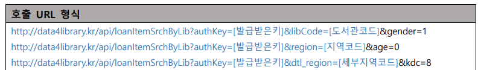

```python
# 도서관 코드 => libCode=111010
# https://www.data4library.kr/libDataL  => 참여도서관 검색 후 도서관코드 입력
# 시작일 2023-01-01
# 종료일 2023-03-20
import requests
url = "http://data4library.kr/api/itemSrch?format=json&authKey=f0529a9c329d42a154317218699cf5f1667b2ea4347d351d8dbff89f7b77a174&libCode=111010& &startDt=2023-01-01&endDt=2023-03-20&pageSize=1000"
r=requests.get(url)
```

```python
data = r.json()
print(data)
```

```
{'response': {'request': {'libCode': '111010', 'startDt': '2023-01-01', 'endDt': '2023-03-20', 'pageSize': '1000'}, 'libNm': '서울특별시교육청남산도서관', 'pageNo': 1, 'pageSize': 1000, 'numFound': 2303, 'resultNum': 1000, 'docs': [{'doc': {'bookname': '장자의 길', 'authors': '토머스 머튼 저', 'publisher': '인간사랑', 'public…
```

```python
books = []
for d in data['response']['docs']:
    books.append(d['doc'])
```

```python
books
```

[output not shown]

```python
# 위 json 데이터를 판다스 데이터프레임 구조로 변환

books_df = pd.DataFrame(books)
books_df.head(2)
```

[output not shown]

### 도서관/지역별 인기대출 도서 조회

```python
import requests
url = "http://data4library.kr/api/loanItemSrchByLib?format=json&authKey=f0529a9c329d42a154317218699cf5f1667b2ea4347d351d8dbff89f7b77a174&region=11&startDt=2023-01-01&endDt=2023-03-20"
r=requests.get(url)
```

```python
data = r.json()
print(data)
```

[output not shown]

```python
books = []
for d in data['response']['docs']:
    books.append(d['doc'])
```

```python
books
```

[output not shown]

```python
# 위 json 데이터를 판다스 데이터프레임 구조로 변환

books_df = pd.DataFrame(books)
books_df.head(2)
```

[output not shown]

```python
#필요한 열만 골라 선택

books_df1 = books_df[["no","bookname","authors","publisher","publication_year","isbn13","addition_symbol","vol","class_no","loan_count"]]
books_df1.head()
```

[output not shown]

```python
# 열 이름 변경

books_df1.columns=["번호","도서명","저자","출판사","발행년도","ISBN","부가기호","권","주제분류번호","대출건수"]
books_df1.head()
```

|  | 번호 | 도서명 | 저자 | 출판사 | 발행년도 | ISBN | 부가기호 | 권 | 주제분류번호 | 대출건수 |
| --- | --- | --- | --- | --- | --- | --- | --- | --- | --- | --- |
| 0 | 1 | 불편한 편의점 :김호연 장편소설 | 지은이: 김호연 | 나무옆의자 | 2021 | 9791161571188 | 03810 |  | 813.7 | 2174 |
| 1 | 2 | 불편한 편의점 :김호연 장편소설 | 지은이: 김호연 | 나무옆의자 | 2022 | 9791161571379 | 03810 | 2 | 813.7 | 1715 |
| 2 | 3 | 달러구트 꿈 백화점.이미예 장편소설 | 지은이: 이미예 | 팩토리나인 | 2020 | 9791165341909 | 03810 |  | 813.7 | 1568 |
| 3 | 4 | 작별인사 :김영하 장편소설 | 지은이: 김영하 | 복복서가 | 2022 | 9791191114225 | 03810 |  | 813.62 | 1553 |
| 4 | 5 | 아버지의 해방일지 :정지아 장편소설 | 지은이: 정지아 | 창비 | 2022 | 9788936438838 | 03810 |  | 813.7 | 1536 |

```python
books_df1.info()
```

```
<class 'pandas.core.frame.DataFrame'>
RangeIndex: 200 entries, 0 to 199
Data columns (total 10 columns):
 #   Column  Non-Null Count  Dtype
---  ------  --------------  -----
 0   번호      200 non-null    int64
 1   도서명     200 non-null    object
 2   저자      200 non-null    object
 3   출판사     200 non-null    object
 4   발행년도    200 non-null    object
 5   ISBN    200 non-null    object
 6   부가기호    200 non-null    object
 7   권       200 non-null    object
 8   주제분류번호  200 non-null    object
 9   대출건수    200 non-null    object
dtypes: int64(1), object(9)
memory usage: 15.8+ KB
```

```python
# csv 파일로 저장
books_df1.to_csv("data/book/seoul_book.csv")
```

```python
import requests
url = "http://data4library.kr/api/itemSrch?format=json&authKey=f0529a9c329d42a154317218699cf5f1667b2ea4347d351d8dbff89f7b77a174&libCode=111010&type=ALL"
r=requests.get(url)
```

```python
data = r.json()
print(data)
```

[output not shown]

```python
books = []
for d in data['response']['docs']:
    books.append(d['doc'])
```

```python
books
```

[output not shown]

```python
# 위 json 데이터를 판다스 데이터프레임 구조로 변환

books_df = pd.DataFrame(books)
books_df.head(2)
```

[output not shown]